# Analisis_componentes_Ppales

Área de Planificación Gestión y Estadística

21/3/2022

```r
# Importar a mano pegando portapales------------------------
# df = as.integer(strsplit(as.character(c("3 1 1 1 3 1 1 1 5")), " ")[[1]])
# df =  matrix(df, nrow = 3, byrow = T)
# df

# Importar definiendo df------------------------------------
# df <- matrix(c(1,2,3, 11,12,13), nrow = 2, ncol = 3, byrow = TRUE,
#                dimnames = list(c("row1", "row2"),
#                                c("C.1", "C.2", "C.3")))
# df

# Importar leyendo-------------------------------------------
#df_raw <- readxl::read_excel("nadadores.xlsx")
#df = df_raw %>% dplyr::select(-Nadador)  # quito columna nombre individuos
df <- readxl::read_excel("aspirantes.xlsx") %>% dplyr::select(-ID)
```

# Exploracion de datos

```r
head(df)
```

```
## # A tibble: 6 × 15
##     PRO   APA   FAC   AMA   SEG   LUC   HON   VEN   EXP   CAR   AMB   CON   POT
##   <dbl> <dbl> <dbl> <dbl> <dbl> <dbl> <dbl> <dbl> <dbl> <dbl> <dbl> <dbl> <dbl>
## 1     6     7     2     5     8     7     8     8     3     8     9     7     5
## 2     9    10     5     8    10     9     9    10     5     9     9     8     8
## 3     7     8     3     6     9     8     9     7     4     9     9     8     6
## 4     5     6     8     5     6     5     9     2     8     4     5     8     7
## 5     6     8     8     8     4     4     9     5     8     5     5     8     8
## 6     7     7     7     6     8     7    10     5     9     6     5     8     6
## # … with 2 more variables: ADA <dbl>, GRU <dbl>
```

```r
skim(df)
```

Data summary

| Name | df |
| --- | --- |
| Number of rows | 48 |
| Number of columns | 15 |
| _______________________ |  |
| Column type frequency: |  |
| numeric | 15 |
| ________________________ |  |
| Group variables | None |

**Variable type: numeric**

| skim_variable | n_missing | complete_rate | mean | sd | p0 | p25 | p50 | p75 | p100 | hist |
| --- | --- | --- | --- | --- | --- | --- | --- | --- | --- | --- |
| PRO | 0 | 1 | 6.00 | 2.67 | 0 | 4.00 | 6.0 | 9.00 | 10 | ▂▇▇▅▇ |
| APA | 0 | 1 | 7.08 | 1.97 | 3 | 6.00 | 7.0 | 8.25 | 10 | ▃▁▇▅▆ |
| FAC | 0 | 1 | 7.08 | 1.99 | 2 | 6.00 | 7.0 | 8.00 | 10 | ▁▃▂▇▅ |
| AMA | 0 | 1 | 6.15 | 2.81 | 0 | 4.00 | 7.0 | 8.00 | 10 | ▂▅▃▇▅ |
| SEG | 0 | 1 | 6.94 | 2.42 | 1 | 5.00 | 8.0 | 9.00 | 10 | ▂▂▅▇▇ |
| LUC | 0 | 1 | 6.31 | 3.17 | 0 | 4.00 | 8.0 | 9.00 | 10 | ▃▅▂▆▇ |
| HON | 0 | 1 | 8.04 | 2.53 | 0 | 8.00 | 9.0 | 10.00 | 10 | ▁▁▁▅▇ |
| VEN | 0 | 1 | 4.85 | 3.44 | 0 | 2.00 | 4.5 | 8.00 | 10 | ▇▆▅▃▆ |
| EXP | 0 | 1 | 4.23 | 3.31 | 0 | 2.00 | 3.0 | 7.25 | 10 | ▇▅▂▂▃ |
| CAR | 0 | 1 | 5.31 | 2.95 | 0 | 3.00 | 5.0 | 8.00 | 10 | ▇▇▇▅▇ |
| AMB | 0 | 1 | 5.98 | 2.94 | 0 | 3.75 | 6.0 | 9.00 | 10 | ▃▆▇▆▇ |
| CON | 0 | 1 | 6.25 | 3.04 | 0 | 4.00 | 7.0 | 8.00 | 10 | ▂▃▃▇▅ |
| POT | 0 | 1 | 5.69 | 3.18 | 0 | 3.75 | 6.0 | 8.00 | 10 | ▇▃▇▇▇ |
| ADA | 0 | 1 | 5.56 | 2.66 | 0 | 4.00 | 5.0 | 7.25 | 10 | ▂▃▇▅▂ |
| GRU | 0 | 1 | 5.96 | 3.30 | 0 | 3.00 | 6.0 | 9.25 | 10 | ▆▅▆▆▇ |

# Analisis PCA

```r
pca =  prcomp(df, center = TRUE, scale. = T) # trabajamos con la matriz correlacion
```

Los elementos center y scale almacenados en el objeto pca contienen la media y desviación típica de las variables originales, previa estandarización (en la escala original).

```r
pca$center
```

```
##      PRO      APA      FAC      AMA      SEG      LUC      HON      VEN
## 6.000000 7.083333 7.083333 6.145833 6.937500 6.312500 8.041667 4.854167
##      EXP      CAR      AMB      CON      POT      ADA      GRU
## 4.229167 5.312500 5.979167 6.250000 5.687500 5.562500 5.958333
```

```r
pca$scale
```

```
##      PRO      APA      FAC      AMA      SEG      LUC      HON      VEN
## 2.673749 1.966023 1.987550 2.805690 2.418072 3.170048 2.534514 3.439381
##      EXP      CAR      AMB      CON      POT      ADA      GRU
## 3.308529 2.947457 2.935401 3.035254 3.183443 2.657036 3.300279
```

La matriz “rotation” proporciona los loadings de los componentes principales (cada columna contiene el vector de loadings de cada componente principal). La función los denomina matriz de rotación ya que si multiplicáramos la matriz de datos por *$rotation*, obtendríamos las coordenadas de los datos en el nuevo sistema rotado de coordenadas. Estas coordenadas se corresponden con los scores de los componentes principales. En *rotation* contiene el valor de los loadings ϕ para cada componente (vector propio, autovector o eigenvector). El número máximo de componentes principales se corresponde con el mínimo(n-1,p),

```r
pca$rotation %>% head()
```

```
##             PC1         PC2         PC3         PC4          PC5         PC6
## PRO -0.16244045 -0.42884630  0.31537452  0.09434720 -0.114181085  0.62123756
## APA -0.21310790  0.03526587 -0.02287769 -0.26217502 -0.870202592 -0.03776744
## FAC -0.04018392 -0.23691912 -0.43046955 -0.63627435  0.212812084  0.22338926
## AMA -0.22507847  0.12979571  0.46582469 -0.34537465  0.128783996  0.11195999
## SEG -0.29048107  0.24889621 -0.24102627  0.17280371 -0.004916442  0.01993905
## LUC -0.31487036  0.13099029 -0.15003717  0.07103303  0.206810333  0.17464295
##              PC7          PC8         PC9       PC10       PC11         PC12
## PRO -0.171115895  0.155367667 -0.41085880 0.03339033 -0.1214575  0.184823366
## APA  0.009998411 -0.009055699  0.07093479 0.01355890  0.1144055  0.004062233
## FAC -0.310998459 -0.043216319  0.06514834 0.28951669  0.1837296 -0.174262044
## AMA  0.130673577 -0.308272942  0.36916926 0.17160739 -0.4170363 -0.024950777
## SEG -0.143008270  0.386487965 -0.12575206 0.22629568 -0.4227854 -0.338609275
## LUC  0.514547094  0.023611660 -0.12424333 0.25024931 -0.0247789 -0.002121069
##             PC13        PC14        PC15
## PRO  0.031531909 -0.09132656 -0.02796467
## APA -0.314356579  0.08715427  0.02201519
## FAC  0.037601862  0.01078840  0.06788021
## AMA -0.059240800 -0.14908682 -0.29828696
## SEG  0.001044381  0.37954743 -0.30163924
## LUC -0.420694539 -0.11324718  0.49906515
```

Cuando existe una alta correlación positiva entre todas las variables, el primer componente principal tiene todas sus coordenadas del mismo signo y puede interpretarse como un promedio ponderado de todas las variables, se interpreta como factor global de ‘Tamaño’. Los restantes componentes se interpretan como factores ”de forma” y típicamente tienen coordenadas positivas y negativas, que implica que contraponen unos grupos de variables frente a otros.

La funciòn tambièn calcula automáticamente el valor de las componentes principales para cada observaciòn o individuo del data set (principal componente score o simplemente scores) mediante la multiplicación de los datos con los loadings como sigue: se tienen que multiplicar los eigenvectors transpuestos por los datos originales centrados y también transpuestos.

```r
pca$x %>% head()
```

```
##             PC1         PC2        PC3        PC4        PC5        PC6
## [1,] -1.2901637  0.48287045 0.62912367  2.5869739 -0.6213659 -1.0894565
## [2,] -3.4975778 -0.03012792 0.59806146  0.9876128 -1.1690391 -0.2291218
## [3,] -2.2062003  0.41185070 0.81637495  1.9421038 -0.6460756 -0.8465128
## [4,]  0.4947594 -0.53592037 0.07591916 -0.7680444  0.7634301 -0.3538965
## [5,] -0.4188854 -0.98975372 0.93320894 -1.2795076 -0.0194975 -0.5037807
## [6,] -0.8004172 -0.51813525 0.35932093 -0.2869733  0.3961281 -0.5018401
##              PC7         PC8        PC9        PC10        PC11        PC12
## [1,]  0.26357328 -0.51249510 -0.5609980 -0.32879666 -0.13969333 -0.03524899
## [2,] -0.14053901 -0.17857744 -0.4405496  0.31636107 -0.37155000  0.23780985
## [3,]  0.05852145 -0.14900301 -0.6525343 -0.37347614 -0.11950532 -0.34017238
## [4,]  0.22275517  1.02593812  0.3401794 -0.84070030  0.54274183 -0.21113324
## [5,]  0.10649501 -0.05104803  0.7215712 -0.58413283  0.77724819  0.43146257
## [6,]  0.19253570  1.33031368 -0.2332049 -0.05686194  0.09415857  0.20592738
##             PC13        PC14        PC15
## [1,]  0.41344762 -0.45702903 -0.03107258
## [2,] -0.15827408  0.08676142 -0.14232944
## [3,] -0.02730903 -0.32315326 -0.03261272
## [4,]  0.20306228  0.23711376  0.04189682
## [5,]  0.25712825  0.12468744 -0.16853126
## [6,] -0.27045265  0.01291638 -0.28460635
```

## Varianza explicada por las CP

La varianza explicada por cada componente principal (correspondiente a los eigenvalores) la obtenemos elevando al cuadrado la desviación estándar:

*desviación estándar de cada componente principal*

```r
pca$sdev
```

```
##  [1] 2.7411301 1.4339809 1.2065734 1.0944851 0.8597399 0.7032632 0.5926735
##  [8] 0.5566884 0.5069137 0.4300121 0.3907433 0.3123509 0.2980248 0.2542307
## [15] 0.1890094
```

*varianza*

```r
pca$sdev^2
```

```
##  [1] 7.51379418 2.05630117 1.45581948 1.19789771 0.73915262 0.49457907
##  [7] 0.35126183 0.30990202 0.25696154 0.18491037 0.15268036 0.09756308
## [13] 0.08881880 0.06463323 0.03572455
```

A traves de summary accedemos a los datos de varición

```r
summary(pca)
```

```
## Importance of components:
##                           PC1    PC2     PC3     PC4     PC5     PC6     PC7
## Standard deviation     2.7411 1.4340 1.20657 1.09449 0.85974 0.70326 0.59267
## Proportion of Variance 0.5009 0.1371 0.09705 0.07986 0.04928 0.03297 0.02342
## Cumulative Proportion  0.5009 0.6380 0.73506 0.81492 0.86420 0.89717 0.92059
##                            PC8     PC9    PC10    PC11   PC12    PC13    PC14
## Standard deviation     0.55669 0.50691 0.43001 0.39074 0.3124 0.29802 0.25423
## Proportion of Variance 0.02066 0.01713 0.01233 0.01018 0.0065 0.00592 0.00431
## Cumulative Proportion  0.94125 0.95838 0.97071 0.98088 0.9874 0.99331 0.99762
##                           PC15
## Standard deviation     0.18901
## Proportion of Variance 0.00238
## Cumulative Proportion  1.00000
```

Tener presente que los autovalores de esta matriz corresponden a la varianza de la componente y por lo tanto debe elevarse al cuadrado el desvío estandar (fila 1)

## Reprsentaciones Graficas: BIPLOT

El biplot tiene la particularidad de facilitar: La interpretación de las distancias entre individuos en términos de similitud en relación a las variables consideradas.  
La búsqueda de grupos o patrones.  
La explicación de las componentes principales utilizando las correlaciones con las variables originales.  
El estudio de las posiciones relativas de los individuos entre sí y respecto de las componentes principales graficadas.

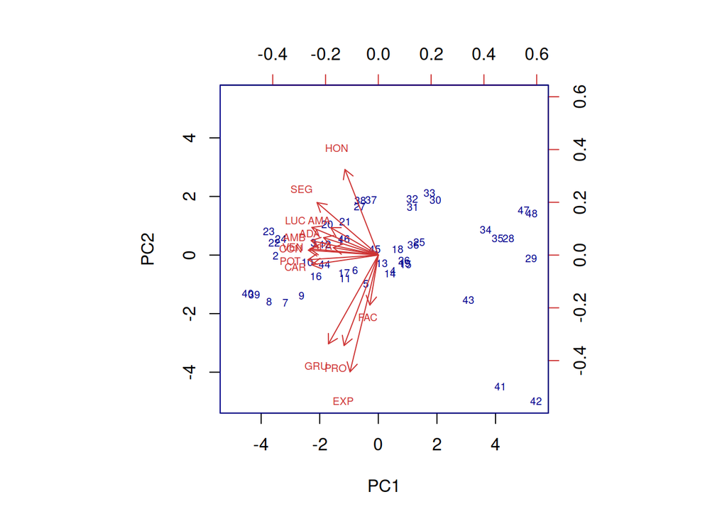

```r
biplot(x = pca, scale = 0, cex = 0.6, col = c("blue4", "brown3"))
```

Interpretacion: Para los vectores (variables), nos fijamos en su longitud y en el ángulo con respecto a los ejes de las componentes principales y entre ellos mismos:

Ángulo: cuanto más paralelo es un vector al eje de una componente, más ha contribuido a la creación de la misma. Con ello obtienes información sobre qué variable(s) ha sido más determinante para crear cada componente, y si entre las variables (y cuales) hay correlaciones. Ángulos pequeños entre vectores representa alta correlación entre las variables implicadas (observaciones con valores altos en una de esas variables tendrá valores altos en la variable o variables correlacionadas); ángulos rectos representan falta de correlación, y ángulos opuestos representan correlación negativa (una observación con valores altos en una de las variables irá acompañado de valores bajos en la otra).

Longitud: cuanto mayor la longitud de un vector relacionado con x variable (en un rango normalizado de 0 a 1), mayor variabilidad de dicha variable está contenida en la representación de las dos componentes del biplot, es decir, mejor está representada su información en el gráfico.

Para los scores (observaciones), nos fijamos en los posibles agrupamientos. Puntuaciones próximas representan observaciones de similares características. Puntuaciones con valores de las variables próximas a la media se sitúan más cerca del centro del biplot (0, 0). El resto representan variabilidades normales o extremas (outliers).

## Proporciòn de Varianza Explicada

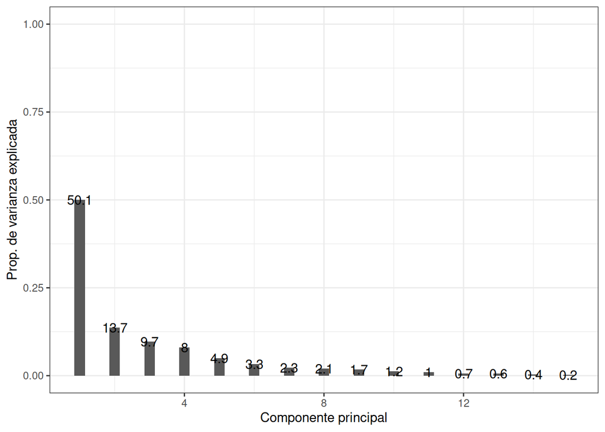

```r
prop_varianza = pca$sdev^2 / sum(pca$sdev^2)

ggplot(data = data.frame(prop_varianza, pc = 1:length(prop_varianza)),
       aes(x = pc, y = prop_varianza)) +
  geom_col(width = 0.3) +
  geom_text(label = round(prop_varianza * 100, digits = 1)) +
  scale_y_continuous(limits = c(0,1)) +
  theme_bw() +
  labs(x = "Componente principal",
       y = "Prop. de varianza explicada")
```

## Proporcioan acumulada en las componentes

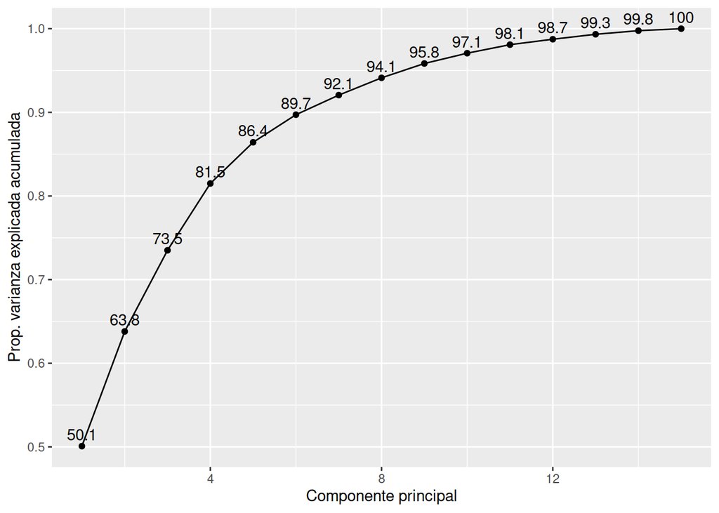

```r
prop_varianza_acum <- cumsum(prop_varianza)

ggplot(data = data.frame(prop_varianza_acum, pc = 1:length(prop_varianza_acum)),
       aes(x = pc, y = prop_varianza_acum, group = 1)) +
  geom_point() +
  geom_line() +
  geom_text(label = round(prop_varianza_acum * 100, digits = 1), vjust =-.5) +
  labs(x = "Componente principal",
       y = "Prop. varianza explicada acumulada")
```

# FactomineR

```r
pca2.nci <- PCA(X = df, scale.unit = TRUE, ncp = 64, graph = FALSE)
```

```r
print(pca2.nci)
```

```
## **Results for the Principal Component Analysis (PCA)**
## The analysis was performed on 48 individuals, described by 15 variables
## *The results are available in the following objects:
##
##    name               description
## 1  "$eig"             "eigenvalues"
## 2  "$var"             "results for the variables"
## 3  "$var$coord"       "coord. for the variables"
## 4  "$var$cor"         "correlations variables - dimensions"
## 5  "$var$cos2"        "cos2 for the variables"
## 6  "$var$contrib"     "contributions of the variables"
## 7  "$ind"             "results for the individuals"
## 8  "$ind$coord"       "coord. for the individuals"
## 9  "$ind$cos2"        "cos2 for the individuals"
## 10 "$ind$contrib"     "contributions of the individuals"
## 11 "$call"            "summary statistics"
## 12 "$call$centre"     "mean of the variables"
## 13 "$call$ecart.type" "standard error of the variables"
## 14 "$call$row.w"      "weights for the individuals"
## 15 "$call$col.w"      "weights for the variables"
```

```r
pca2.nci$eig
```

```
##         eigenvalue percentage of variance cumulative percentage of variance
## comp 1  7.51379418             50.0919612                          50.09196
## comp 2  2.05630117             13.7086745                          63.80064
## comp 3  1.45581948              9.7054632                          73.50610
## comp 4  1.19789771              7.9859847                          81.49208
## comp 5  0.73915262              4.9276841                          86.41977
## comp 6  0.49457907              3.2971938                          89.71696
## comp 7  0.35126183              2.3417455                          92.05871
## comp 8  0.30990202              2.0660134                          94.12472
## comp 9  0.25696154              1.7130770                          95.83780
## comp 10 0.18491037              1.2327358                          97.07053
## comp 11 0.15268036              1.0178691                          98.08840
## comp 12 0.09756308              0.6504205                          98.73882
## comp 13 0.08881880              0.5921253                          99.33095
## comp 14 0.06463323              0.4308882                          99.76184
## comp 15 0.03572455              0.2381637                         100.00000
```

Como es de esperar, el eigenvalor (varianza explicada) es mayor en la primera componente que en las subsiguientes.

```r
summary(pca2.nci)
```

```
##
## Call:
## PCA(X = df, scale.unit = TRUE, ncp = 64, graph = FALSE)
##
##
## Eigenvalues
##                        Dim.1   Dim.2   Dim.3   Dim.4   Dim.5   Dim.6   Dim.7
## Variance               7.514   2.056   1.456   1.198   0.739   0.495   0.351
## % of var.             50.092  13.709   9.705   7.986   4.928   3.297   2.342
## Cumulative % of var.  50.092  63.801  73.506  81.492  86.420  89.717  92.059
##                        Dim.8   Dim.9  Dim.10  Dim.11  Dim.12  Dim.13  Dim.14
## Variance               0.310   0.257   0.185   0.153   0.098   0.089   0.065
## % of var.              2.066   1.713   1.233   1.018   0.650   0.592   0.431
## Cumulative % of var.  94.125  95.838  97.071  98.088  98.739  99.331  99.762
##                       Dim.15
## Variance               0.036
## % of var.              0.238
## Cumulative % of var. 100.000
##
## Individuals (the 10 first)
##         Dist    Dim.1    ctr   cos2    Dim.2    ctr   cos2    Dim.3    ctr
## 1   |  3.459 |  1.304  0.471  0.142 | -0.488  0.241  0.020 |  0.636  0.578
## 2   |  3.989 |  3.535  3.464  0.785 |  0.030  0.001  0.000 |  0.604  0.523
## 3   |  3.418 |  2.230  1.378  0.426 | -0.416  0.176  0.015 |  0.825  0.974
## 4   |  2.071 | -0.500  0.069  0.058 |  0.542  0.297  0.068 |  0.077  0.008
## 5   |  2.411 |  0.423  0.050  0.031 |  1.000  1.014  0.172 |  0.943  1.273
## 6   |  1.917 |  0.809  0.181  0.178 |  0.524  0.278  0.075 |  0.363  0.189
## 7   |  3.738 |  3.202  2.842  0.734 |  1.651  2.763  0.195 |  0.263  0.099
## 8   |  4.218 |  3.761  3.922  0.795 |  1.603  2.603  0.144 |  0.007  0.000
## 9   |  3.243 |  2.639  1.931  0.662 |  1.404  1.998  0.188 |  0.716  0.733
## 10  |  4.502 |  2.458  1.675  0.298 |  0.241  0.059  0.003 | -3.471 17.239
##       cos2
## 1    0.034 |
## 2    0.023 |
## 3    0.058 |
## 4    0.001 |
## 5    0.153 |
## 6    0.036 |
## 7    0.005 |
## 8    0.000 |
## 9    0.049 |
## 10   0.594 |
##
## Variables (the 10 first)
##        Dim.1    ctr   cos2    Dim.2    ctr   cos2    Dim.3    ctr   cos2
## PRO |  0.445  2.639  0.198 |  0.615 18.391  0.378 |  0.381  9.946  0.145 |
## APA |  0.584  4.541  0.341 | -0.051  0.124  0.003 | -0.028  0.052  0.001 |
## FAC |  0.110  0.161  0.012 |  0.340  5.613  0.115 | -0.519 18.530  0.270 |
## AMA |  0.617  5.066  0.381 | -0.186  1.685  0.035 |  0.562 21.699  0.316 |
## SEG |  0.796  8.438  0.634 | -0.357  6.195  0.127 | -0.291  5.809  0.085 |
## LUC |  0.863  9.914  0.745 | -0.188  1.716  0.035 | -0.181  2.251  0.033 |
## HON |  0.433  2.500  0.188 | -0.581 16.439  0.338 |  0.343  8.062  0.117 |
## VEN |  0.889 10.514  0.790 | -0.042  0.087  0.002 | -0.224  3.459  0.050 |
## EXP |  0.367  1.797  0.135 |  0.793 30.596  0.629 |  0.100  0.682  0.010 |
## CAR |  0.864  9.927  0.746 |  0.066  0.214  0.004 | -0.096  0.634  0.009 |
```

# Representacion

Cabe destacar que la representación gráfica de las observaciones y las variables es distinta: las observaciones se representan mediante sus proyecciones, mientras que las variables se representan mediante sus correlaciones. La correlación entre una componente y una variable estima la información que comparten -> loadings, por lo que las variables se pueden representar como puntos en el espacio de los componentes utilizando sus loadings como coordenadas.

Observaciones Se muestran dos ejemplos para representar las observaciones sobre las dos primeras componentes principales:

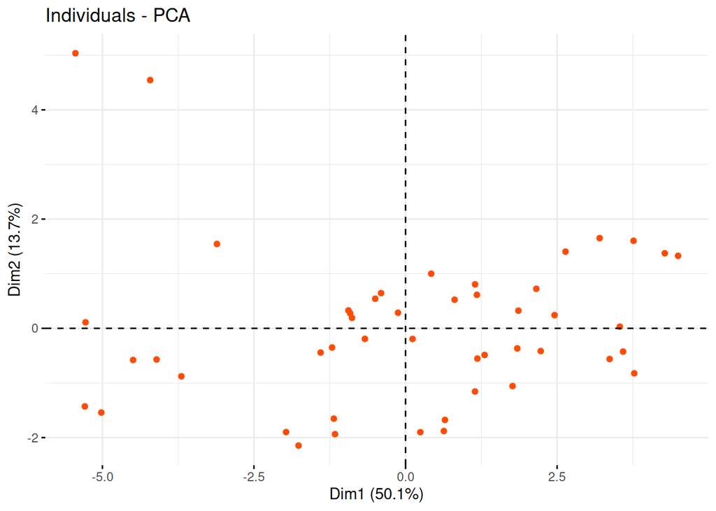

```r
fviz_pca_ind(pca2.nci, geom.ind = "point",
             col.ind = "#FC4E07",
             axes = c(1, 2), # axes 1 y 2 se corresponden con PC1 y PC2, pudiendo escoger otros
             pointsize = 1.5)
```

# Representacion de Variables

Para representar las variables sobre las dos primeras componentes principales podemos utilizar la función fviz_pca_var() del paquete factoextra. La correlación entre una variable y una componente principal se utiliza como la coordenada de dicha variable sobre la componente principal. De esta manera podemos obtener un gráfico de correlación de variables:

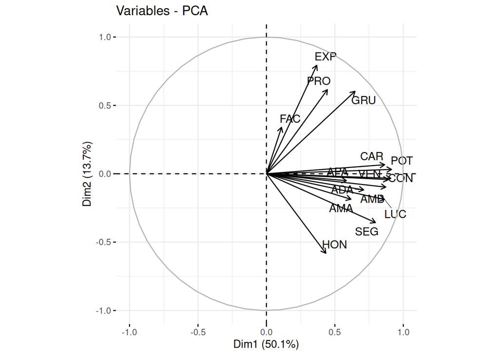

```r
fviz_pca_var(pca2.nci, col.var = "black",repel = TRUE)
```

Grafico muestra: - %varianza expliada por cada componente (dim1 y dim2)

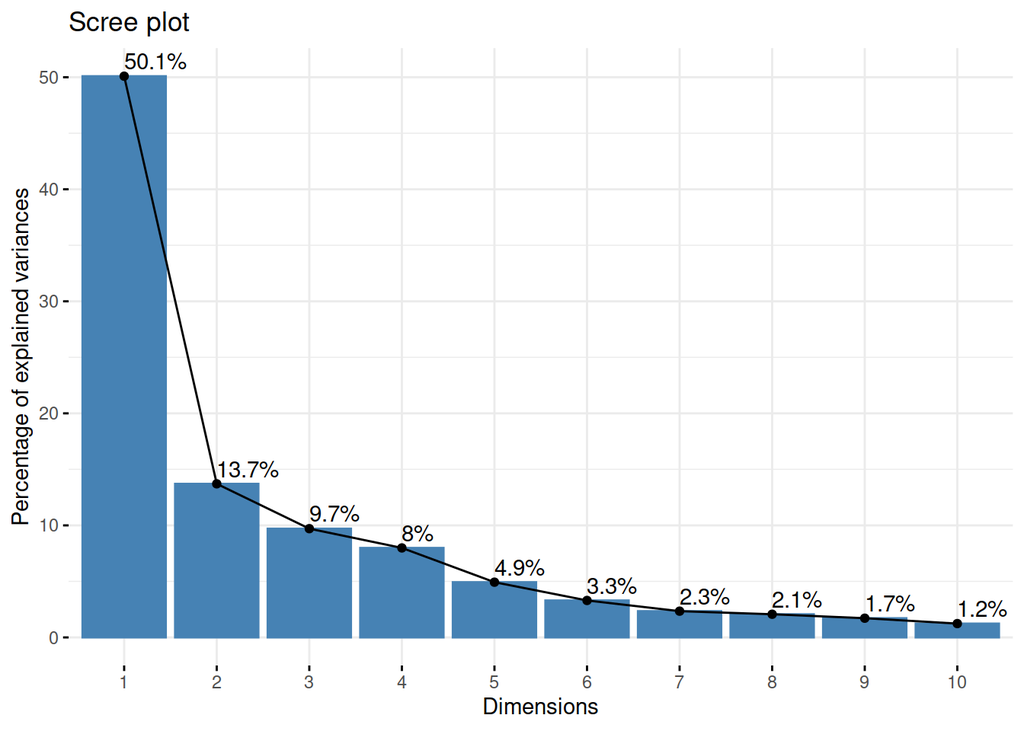

```r
fviz_screeplot(pca2.nci, addlabels = TRUE)
```

# Contribuciones de las variables en los ejes

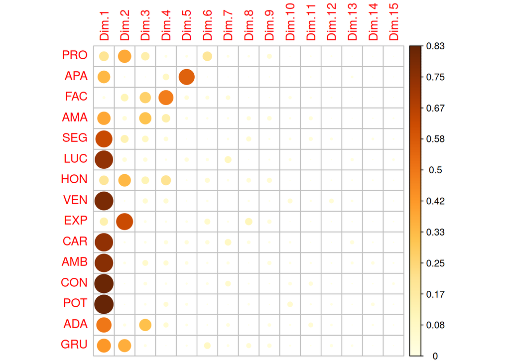

```r
var <- get_pca_var(pca2.nci)
corrplot(var$cos2, is.corr=FALSE)
```

# Conclusión

- Considerando el criterio de Kaiser (más el ajuste derivado de las simulaciones de Montecarlo) que admite autovalores hasta 0.7, las componentes que se emplearían son: comp1, comp2, comp3, comp4, comp5.
- Considerando el criterio de variabilidad explicada del componente, eligiendo aquellas cuyo % de variabilidad no sea menor a 5%, las componentes que se emplearían son: comp1, comp2, comp3, comp4.